# Homework Week 13

Cesar L. Espitia

4/30/2017

## Assignment – NoSQL Migration

I chose Neo4j for this assignment. I was very intrigued in the capabilities with graphing. I am also using the original flights data that I had from my bridge program.

## MySQL Export

The following was how i exported the table from MySQL into a CSV for import into Neo4j.

```cpp
library(RMySQL)
library(RNeo4j)
library(dplyr)


con <- dbConnect(RMySQL::MySQL(),
                 dbname = "flights",
                 host = "localhost",
                 port = 3306,
                 user = "root",
                 password = "Espiti@1")

table_names <- dbListTables(con)

flights <- dbReadTable(con, "flights")
flights <- mutate(flights, id = as.numeric(rownames(flights)))
##flights <- subset(flights, select = c(flights$id,flights$tailnum, flights$flight, flights$tailnum, flights$dest, flights$origin))

write.csv(flights, file='flights.csv', row.names=FALSE)

dbDisconnect(con)
```

## Neo4j Import

The following was how I imported the data into Neo4j. Of special note was using the information from the neo4j blog. http://neo4j.com/blog/upload-last-fm-data-neo4j-rneo4j-transactional-endpoint/.

It was a bit difficult to retrofit the code to fit my needs on the flights database. I used the flight and tailnum as the constraint for the graph.

The code was the imported in chunks to avoid R crashing per the blog. All columns from the original table were imported.

```cpp
path <- ("/Users/cesarespitia/Documents/CUNYMSDA/Data 607/CUNYDATA607/Week 13/flights.csv")
con<- file(path, open="r")
flightneo<- read.csv(con, header=TRUE, stringsAsFactors = FALSE)

close(con)
head(flightneo)

graph = startGraph("http://localhost:7474/db/data/", username="neo4j", password="Espiti@1")
clear(graph, input = FALSE)

addConstraint(graph, "PlaneID", "tailnum")
addConstraint(graph, "flightno","flights")

#using import guide from neo4j
query = "
MERGE (o:origin {name:{origin}})
MERGE (d:dest {year:{dest}})
MERGE (f:flight {year:{year},month:{month},day:{day},dep_time:{dep_time},dep_delay:{dep_delay},
                arr_time:{arr_time},arr_delay:{arr_delay},carrier:{carrier},tailnum:{tailnum},
                flight:{flight},origin:{origin},dest:{dest},air_time:{air_time},distance:{distance},
                hour:{hour},minute:{minute},id:{id}})
CREATE (o)<-[:FROM]-(f)-[:TO]->(d)
"

fn = newTransaction(graph)

for (i in 1:nrow(flightneo)) {
  # Upload in blocks of 1000.
  if(i %% 1000 == 0) {
    # Commit current transaction.
    commit(fn)
    # Open new transaction.
    fn = newTransaction(graph)
  }

  # Append paramaterized Cypher query to transaction.
  appendCypher(fn,
               query,
               origin = flightneo$origin[i],
               dest = flightneo$dest[i],
               year = flightneo$year[i],
               month = flightneo$month[i],
               day = flightneo$day[i],
               dep_time = flightneo$dep_time[i],
               dep_delay = flightneo$dep_delay[i],
               arr_time = flightneo$arr_time[i],
               arr_delay = flightneo$arr_delay[i],
               carrier = flightneo$carrier[i],
               tailnum = flightneo$tailnum[i],
               flight = flightneo$flight[i],
               air_time = flightneo$air_time[i],
               distance = flightneo$distance[i],
               hour = flightneo$hour[i],
               minute = flightneo$minute[i],
               id = flightneo$id[i]
               )
}

commit(fn)
print("All done!")
```

## Graphing

The data was then transformed into node pairing using the MATCH function within Neo4j.

My goal is to match origin - count of flights - destination. This is to show the number of flights that occur from each origin to each destination.

```cpp
#create relationships
query = "MATCH (a:origin), (b:counts) where (a.name) = (b.origin) CREATE (a)-[:count_of]->(b)"

fn = newTransaction(graph)
appendCypher(fn, query)
commit(fn)

query = "MATCH (a:counts), (b:dest) where (a.year) = (b.dest) CREATE (a)-[:destcount]->(b)"

fn = newTransaction(graph)
appendCypher(fn, query)
commit(fn)

graph = startGraph("http://localhost:7474/db/data/", username="neo4j", password="Espiti@1")
browse(graph)

MATCH (c:origin) -[x:count_of]-(c1:counts)-[:destcount]-(d:dest) WHERE toInt(c1.flightno) = 1141 AND toString(d.dest) = "JFK" return c,x,c1,d
```

However, it became quickly apparent that I’m missing something critical. In further investigating the data, it seems that the origin - coutn of portion works. Yet, I couldn’t get the pairing to match to the destination. I’m not sure if its becasue the relationship between count of flights doesnt exist between origin and destionation.

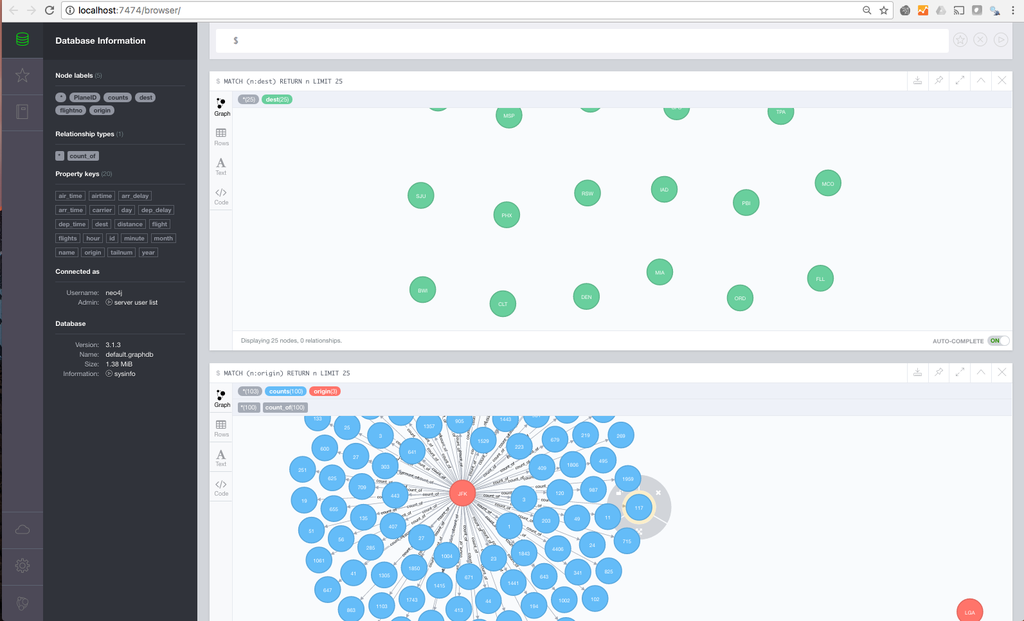

Figure 1. Neo4j Investigation.

I believe I might have simplified the problem overtly by assuming that by grouping all the other columns besides origina and destination that counts would line up accordingly.

In clicking around the nodes in Neo4j, i notice I can’t seem to get a pair matched up. I might have to redo the table and create a new one that has this information.

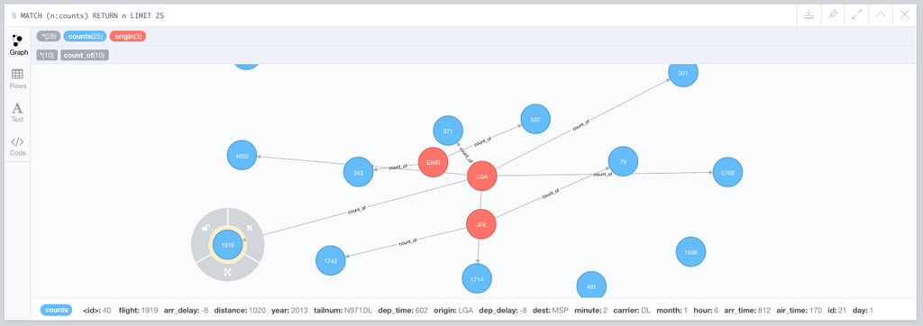

Figure 1. Neo4j Incomplete Matches.

## Comparisons

Certain liberties are gone when you migrate to a NoSQL database. For creatures that are used to structure and the ability to query easily, they may find NoSQL harder to use like I did. However, it is easier to develop mini tables that can later be correlated together.